# Day 1: Introduction to GEOS and First Hands-on PM2.5 Analysis

Technical Training on GEOS Data for Air Quality Monitoring in Lao PDR  
Bangkok, 7 September 2026

This notebook supports the first day of training. It introduces GEOS PM2.5 data, opens a sample NetCDF file, visualizes PM2.5 over mainland Southeast Asia, and compares GEOS estimates with Thai PCD ground observations.

## Learning Goals

By the end of this notebook, participants should be able to:

- open a GEOS NetCDF file with Python;
- inspect dimensions, coordinates, and variables;
- calculate or read PM2.5 fields;
- map GEOS PM2.5 over the Laos/Thailand region;
- compare GEOS PM2.5 with ground-monitor observations;
- interpret simple validation statistics.

```python
from pathlib import Path
import warnings

import numpy as np
import pandas as pd
import xarray as xr
import matplotlib.pyplot as plt

warnings.filterwarnings("ignore")

ROOT = Path("..").resolve()
DATA = ROOT / "data"
OUT = ROOT / "outputs" / "day1"
OUT.mkdir(parents=True, exist_ok=True)

GEOS_FILE = DATA / "geos_sample" / "sample_geos_20230505_laos_subset.nc"
PCD_FILE = DATA / "collocated_pairs" / "thai_pcd_geos_collocated_day1_sample.csv"
PCD_META_FILE = DATA / "station_metadata" / "thailand_pcd_station_metadata.csv"

print("GEOS file:", GEOS_FILE)
print("PCD sample:", PCD_FILE)
```

```
Matplotlib is building the font cache; this may take a moment.
```

```
GEOS file: /Volumes/Personal2/ADPC_UAH/GEOS_Training_Bangkok_2026/data/geos_sample/sample_geos_20230505_laos_subset.nc
PCD sample: /Volumes/Personal2/ADPC_UAH/GEOS_Training_Bangkok_2026/data/collocated_pairs/thai_pcd_geos_collocated_day1_sample.csv
```

## 1. Open and Inspect GEOS Data

GEOS data are distributed as gridded NetCDF files. The first check is always metadata: dimensions, coordinates, units, and variable names.

```python
ds = xr.open_dataset(GEOS_FILE)
ds
```

```
<xarray.Dataset> Size: 3MB
Dimensions:    (lat: 43, lon: 42, time: 24)
Coordinates:
  * lat        (lat) float64 344B 13.0 13.25 13.5 13.75 ... 23.0 23.25 23.5
  * lon        (lon) float64 336B 97.19 97.5 97.81 98.12 ... 109.4 109.7 110.0
  * time       (time) datetime64[ns] 192B 2023-05-05T01:30:00 ... 2023-05-07T...
Data variables: (12/16)
    DUSMASS25  (lat, lon, time) float32 173kB ...
    SSSMASS25  (lat, lon, time) float32 173kB ...
    BCSMASS    (lat, lon, time) float32 173kB ...
    OCSMASS    (lat, lon, time) float32 173kB ...
    SO4SMASS   (lat, lon, time) float32 173kB ...
    SO2SMASS   (lat, lon, time) float32 173kB ...
    ...         ...
    QV10M      (lat, lon, time) float32 173kB ...
    T10M       (lat, lon, time) float32 173kB ...
    T500       (lat, lon, time) float32 173kB ...
    T850       (lat, lon, time) float32 173kB ...
    U10M       (lat, lon, time) float32 173kB ...
    V10M       (lat, lon, time) float32 173kB ...
```

```python
print("Dimensions:")
for name, size in ds.sizes.items():
    print(f"  {name}: {size}")

print("\nVariables:")
for name in list(ds.data_vars):
    units = ds[name].attrs.get("units", "")
    desc = ds[name].attrs.get("long_name", ds[name].attrs.get("description", ""))
    print(f"  {name:12s} {units:12s} {desc}")
```

```
Dimensions:
  lat: 43
  lon: 42
  time: 24

Variables:
  DUSMASS25    μg/m³        DUSMASS25
  SSSMASS25    μg/m³        SSSMASS25
  BCSMASS      μg/m³        BCSMASS
  OCSMASS
  SO4SMASS     μg/m³        SO4SMASS
  SO2SMASS     μg/m³        SO2SMASS
  TOTEXTTAU    μg/m³        TOTEXTTAU
  PS
  Q500
  Q850
  QV10M
  T10M         kelvin       T10M
  T500
  T850
  U10M
  V10M
```

## 2. PM2.5 Field

Some GEOS-derived files include a ready-made `PM25` or `GEOSPM25` field. If not, PM2.5 can be approximated from aerosol species. In this sample file, we calculate a training-demo PM2.5 field from available species and use zero for missing species.

```python
def species_or_zero(dataset, name, template_name="DUSMASS25"):
    if name in dataset:
        return dataset[name]
    print(f"Warning: {name} is missing; using zero contribution.")
    return xr.zeros_like(dataset[template_name])


if "GEOSPM25" in ds:
    pm25 = ds["GEOSPM25"]
elif "PM25" in ds:
    pm25 = ds["PM25"]
else:
    pm25 = (
        species_or_zero(ds, "DUSMASS25")
        + species_or_zero(ds, "SSSMASS25")
        + species_or_zero(ds, "BCSMASS")
        + species_or_zero(ds, "OCSMASS")
        + species_or_zero(ds, "SO4SMASS")
        + species_or_zero(ds, "NISMASS25")
    )

pm25.name = "PM25_demo"
pm25
```

```
<xarray.DataArray 'PM25_demo' (lat: 43, lon: 42, time: 24)> Size: 173kB
array([[[ 8.789087 , 13.822966 , 13.05591  , ...,  5.084271 ,
          4.828648 ,  4.2915735],
        [ 9.425932 , 13.695867 , 14.000859 , ...,  5.90001  ,
          4.9376645,  4.697871 ],
        [10.879269 , 12.3493595, 13.672077 , ...,  6.1288905,
          5.533622 ,  4.969766 ],
        ...,
        [10.511135 , 20.658047 , 20.95337  , ..., 21.919874 ,
         24.810886 , 22.231117 ],
        [11.426314 , 19.40749  , 18.258764 , ..., 21.97527  ,
         22.940514 , 25.27838  ],
        [11.319449 , 18.294268 , 18.384275 , ..., 20.7655   ,
         20.951448 , 21.405294 ]],

       [[ 9.612207 , 14.359069 , 14.292397 , ...,  5.804023 ,
          5.032887 ,  4.638546 ],
        [ 9.765684 , 12.849582 , 14.064524 , ...,  6.2994204,
          5.3426685,  4.690638 ],
        [10.597553 , 10.432372 , 13.049073 , ...,  6.5377088,
          5.9246902,  4.8813634],
...
        [17.667885 , 23.525679 , 22.033857 , ..., 36.808517 ,
         31.40252  , 30.652466 ],
        [19.822453 , 24.571596 , 23.661856 , ..., 38.61432  ,
         43.34492  , 42.319805 ],
        [15.829128 , 25.563856 , 24.64047  , ..., 37.68777  ,
         37.58799  , 39.116337 ]],

       [[15.095402 , 10.273666 ,  7.598963 , ..., 10.37144  ,
         10.654491 , 10.669207 ],
        [14.017464 , 10.161146 ,  6.8223305, ..., 10.381697 ,
         10.60981  , 10.642326 ],
        [13.496523 , 10.214124 ,  6.7233377, ..., 10.51471  ,
         10.642666 , 10.552401 ],
        ...,
        [18.963602 , 23.429272 , 22.781464 , ..., 29.82735  ,
         29.727343 , 29.696018 ],
        [25.459042 , 25.249168 , 24.24848  , ..., 34.872547 ,
         33.872932 , 33.716667 ],
        [27.4389   , 28.88533  , 26.374876 , ..., 44.754147 ,
         42.939934 , 42.870087 ]]], dtype=float32)
Coordinates:
  * lat      (lat) float64 344B 13.0 13.25 13.5 13.75 ... 22.75 23.0 23.25 23.5
  * lon      (lon) float64 336B 97.19 97.5 97.81 98.12 ... 109.4 109.7 110.0
  * time     (time) datetime64[ns] 192B 2023-05-05T01:30:00 ... 2023-05-07T22...
Attributes:
    units:        μg/m³
    long_name:    DUSMASS25
    description:  DUSMASS25
```

## 3. Map GEOS PM2.5

The map below uses one time step from the sample file. Participants can change `time_index` to inspect different hours.

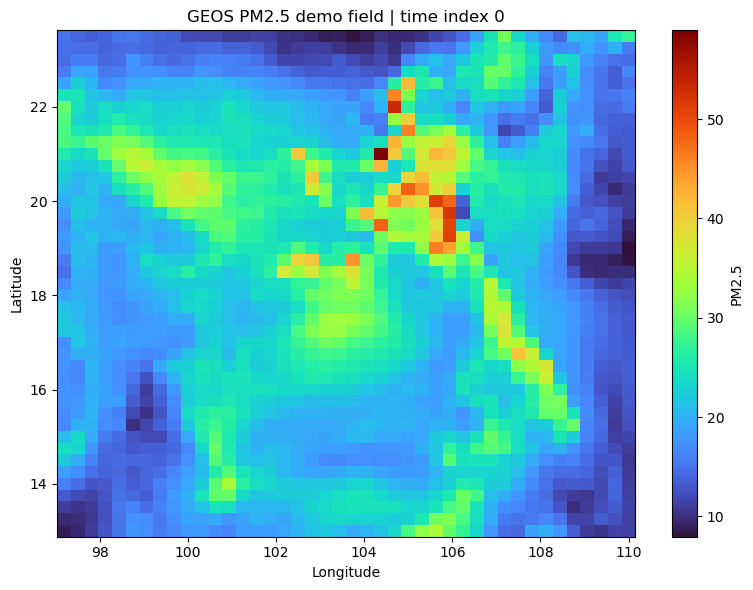

```python
time_index = 0
field = pm25.isel(time=time_index)

plt.figure(figsize=(8, 6))
im = plt.pcolormesh(ds["lon"], ds["lat"], field, shading="auto", cmap="turbo")
plt.colorbar(im, label="PM2.5")
plt.xlabel("Longitude")
plt.ylabel("Latitude")
plt.title(f"GEOS PM2.5 demo field | time index {time_index}")
plt.tight_layout()
plt.savefig(OUT / "day1_geos_pm25_map.png", dpi=200)
plt.show()
```

## 4. Load Thai PCD Collocated Example

This example uses Thai Pollution Control Department ground observations that have already been averaged to the same 3-hour UTC windows used in the GEOS forecast files and collocated to the nearest GEOS grid point.

```python
pcd = pd.read_csv(PCD_FILE, parse_dates=["datetime_utc", "datetime_local", "initialization_time"])
pcd.head()
```

|  | network | station_code | station_name | station_lat | station_lon | geos_grid_index | geos_lat_index | geos_lon_index | geos_grid_lat | geos_grid_lon | ... | BCSMASS | DUSMASS25 | OCSMASS | SO2SMASS | SO4SMASS | SSSMASS25 | TOTEXTTAU | PM25 | BC_MLPM25 | GEOSPM25 |
| --- | --- | --- | --- | --- | --- | --- | --- | --- | --- | --- | --- | --- | --- | --- | --- | --- | --- | --- | --- | --- | --- |
| 0 | PCD | th02 | Bansomdejchaopraya Rajabhat University | 13.732994 | 100.488239 | 5873 | 35 | 133 | 13.75 | 100.625 | ... | 1.840823 | 1.145978 | 14.901174 | 17.462297 | 7.271083 | 0.562996 | 0.192697 | 51.457069 | 51.457069 | 40.369648 |
| 1 | PCD | th03 | Highway NO.3902 km.13 +600 | 13.636514 | 100.414262 | 5872 | 35 | 132 | 13.75 | 100.312 | ... | 1.564336 | 1.096865 | 12.791146 | 14.959369 | 6.834526 | 0.492965 | 0.181711 | 46.837023 | 46.837023 | 35.575703 |
| 2 | PCD | th08 | Prabadang Rehabiltation Center | 13.664023 | 100.543406 | 5873 | 35 | 133 | 13.75 | 100.625 | ... | 1.840823 | 1.145978 | 14.901174 | 17.462297 | 7.271083 | 0.562996 | 0.192697 | 51.457069 | 51.457069 | 40.369648 |
| 3 | PCD | th10 | National Housing Authority Klongchan | 13.779539 | 100.645654 | 5873 | 35 | 133 | 13.75 | 100.625 | ... | 1.840823 | 1.145978 | 14.901174 | 17.462297 | 7.271083 | 0.562996 | 0.192697 | 51.457069 | 51.457069 | 40.369648 |
| 4 | PCD | th11 | National Housing Huaykwang | 13.775516 | 100.569206 | 5873 | 35 | 133 | 13.75 | 100.625 | ... | 1.840823 | 1.145978 | 14.901174 | 17.462297 | 7.271083 | 0.562996 | 0.192697 | 51.457069 | 51.457069 | 40.369648 |

5 rows × 38 columns

```python
print("Rows:", len(pcd))
print("Stations:", pcd["station_code"].nunique())
print("UTC range:", pcd["datetime_utc"].min(), "to", pcd["datetime_utc"].max())
pcd[["observed_pm25", "GEOSPM25", "PM25", "BC_MLPM25", "geos_distance_km"]].describe()
```

```
Rows: 12000
Stations: 69
UTC range: 2020-12-31 19:30:00 to 2021-01-26 04:30:00
```

|  | observed_pm25 | GEOSPM25 | PM25 | BC_MLPM25 | geos_distance_km |
| --- | --- | --- | --- | --- | --- |
| count | 12000.000000 | 12000.000000 | 12000.000000 | 12000.000000 | 12000.000000 |
| mean | 39.374444 | 34.678055 | 45.048540 | 45.048540 | 11.591661 |
| std | 23.720338 | 21.045952 | 22.152093 | 22.152093 | 4.085030 |
| min | 1.000000 | 4.365408 | 6.287362 | 6.287362 | 2.456694 |
| 25% | 22.666667 | 20.051193 | 26.890237 | 26.890237 | 9.058055 |
| 50% | 33.333333 | 28.920327 | 38.788327 | 38.788327 | 12.240009 |
| 75% | 50.333333 | 43.065337 | 63.603977 | 63.603977 | 14.820120 |
| max | 211.666667 | 161.876663 | 101.734331 | 101.734331 | 20.805048 |

## 5. Validation Metrics

These metrics are useful for first-pass model evaluation:

- **Mean bias**: average model minus observation.
- **RMSE**: typical error magnitude.
- **Correlation r**: timing/co-variability.
- **IOA**: index of agreement, where values closer to 1 indicate better agreement.

```python
def metrics(obs, pred):
    obs = np.asarray(obs, dtype=float)
    pred = np.asarray(pred, dtype=float)
    mask = np.isfinite(obs) & np.isfinite(pred)
    obs = obs[mask]
    pred = pred[mask]
    n = len(obs)
    bias = float(np.mean(pred - obs))
    rmse = float(np.sqrt(np.mean((pred - obs) ** 2)))
    r = float(np.corrcoef(obs, pred)[0, 1]) if n > 1 else np.nan
    denom = np.sum((np.abs(pred - np.mean(obs)) + np.abs(obs - np.mean(obs))) ** 2)
    ioa = 1 - np.sum((pred - obs) ** 2) / denom if denom > 0 else np.nan
    slope = float(np.polyfit(obs, pred, 1)[0]) if n > 1 else np.nan
    return pd.Series({"N": n, "Bias": bias, "RMSE": rmse, "r": r, "Slope": slope, "IOA": ioa})


summary = pd.DataFrame({
    "GEOSPM25": metrics(pcd["observed_pm25"], pcd["GEOSPM25"]),
    "PM25": metrics(pcd["observed_pm25"], pcd["PM25"]),
    "BC_MLPM25": metrics(pcd["observed_pm25"], pcd["BC_MLPM25"]),
}).T
summary
```

|  | N | Bias | RMSE | r | Slope | IOA |
| --- | --- | --- | --- | --- | --- | --- |
| GEOSPM25 | 12000.0 | -4.696390 | 22.087403 | 0.540597 | 0.479646 | 0.720721 |
| PM25 | 12000.0 | 5.674096 | 21.682679 | 0.585578 | 0.546863 | 0.751776 |
| BC_MLPM25 | 12000.0 | 5.674096 | 21.682679 | 0.585578 | 0.546863 | 0.751776 |

## 6. Scatterplot: GEOS vs. Thai PCD

The 1:1 line is the ideal case. Points below the line indicate underprediction; points above the line indicate overprediction.

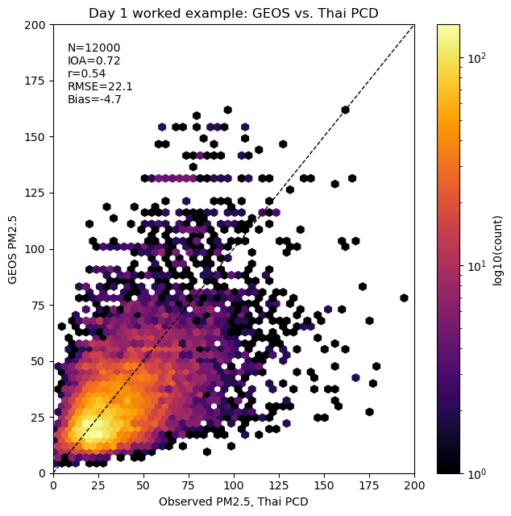

```python
obs = pcd["observed_pm25"]
pred = pcd["GEOSPM25"]
metric = metrics(obs, pred)

plt.figure(figsize=(6.5, 6.5))
plt.hexbin(obs, pred, gridsize=55, bins="log", cmap="inferno", mincnt=1)
plt.plot([0, 200], [0, 200], "k--", linewidth=1)
plt.xlim(0, 200)
plt.ylim(0, 200)
plt.xlabel("Observed PM2.5, Thai PCD")
plt.ylabel("GEOS PM2.5")
plt.title("Day 1 worked example: GEOS vs. Thai PCD")
plt.colorbar(label="log10(count)")
txt = "\n".join([
    f"N={metric['N']:.0f}",
    f"IOA={metric['IOA']:.2f}",
    f"r={metric['r']:.2f}",
    f"RMSE={metric['RMSE']:.1f}",
    f"Bias={metric['Bias']:.1f}",
])
plt.text(0.04, 0.96, txt, transform=plt.gca().transAxes, va="top", ha="left")
plt.tight_layout()
plt.savefig(OUT / "day1_geos_vs_pcd_scatter.png", dpi=200)
plt.show()
```

## 7. Time Series at One Station

Choose one PCD station and compare observed and GEOS PM2.5 through time.

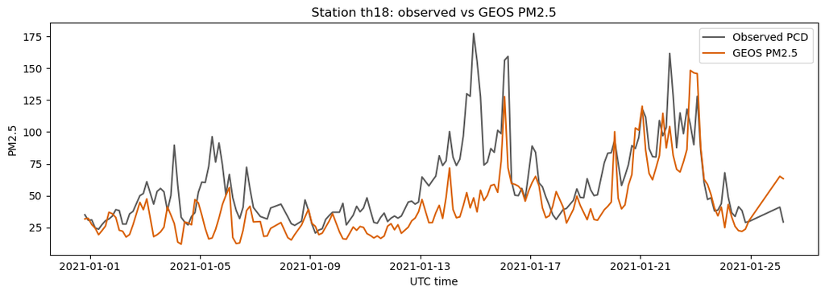

```python
station = pcd["station_code"].value_counts().index[0]
one = pcd[pcd["station_code"].eq(station)].sort_values("datetime_utc")

plt.figure(figsize=(11, 4))
plt.plot(one["datetime_utc"], one["observed_pm25"], color="0.35", label="Observed PCD")
plt.plot(one["datetime_utc"], one["GEOSPM25"], color="#d95f02", label="GEOS PM2.5")
plt.ylabel("PM2.5")
plt.xlabel("UTC time")
plt.title(f"Station {station}: observed vs GEOS PM2.5")
plt.legend()
plt.tight_layout()
plt.savefig(OUT / f"day1_station_{station}_timeseries.png", dpi=200)
plt.show()
```

## 8. Participant Exercise

1. Change the selected PCD station and rerun the time series.
2. Replace `GEOSPM25` with `PM25` in the scatterplot.
3. Filter to one day or one station and compare the metrics.
4. Explain whether GEOS is biased high or low for your selected case.